## Football Knowledge Question 2

#### How would you go about making a compelling argument for attempting to convert more 4th downs to an NFL coaching staff?

As the presence of analytics in the NFL has continued to increase, teams have attempted to convert more 4th downs. The visualization below shows the trend of attempts to convert 4th downs over the past 10 years using data from nflfastR.

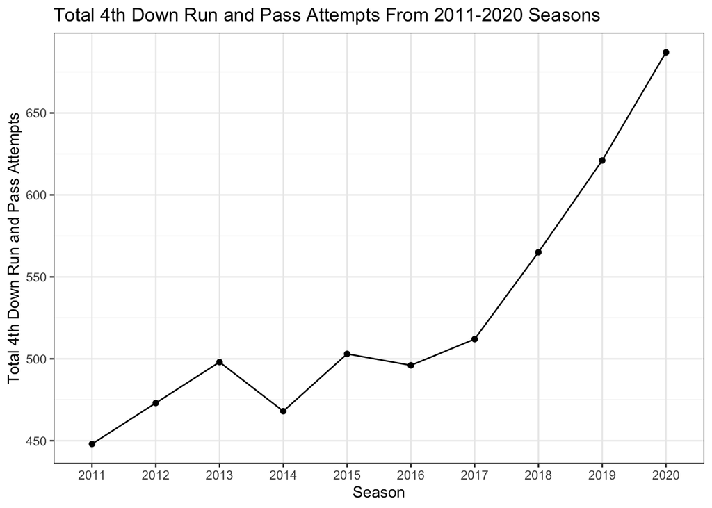

In the past 3 years, there has been a steep increase in the number of attempts which can be traced back to when analytics started to highlight the advantage of going for it on 4th down in certain situations. Each play during a game has an associated win probability which measures the team’s likelihood of winning the game based on the current and previous plays. Ultimately, converting a 4th down increases the team’s win probability as they either keep their drive alive or score. Teams falling behind on this trend are missing out on opportunities to gain a competitive advantage to increase their win probability. Traditionally, coaches have chosen to put their kicking unit on the field in a 4th down situation unless it is late in the game and they need to score. However, machine learning models have shown that in many situations the best chance of winning comes from going for it on 4th down. The situations where going for it is supported are those where the reward of a first down outweighs the risk of turning it over on downs. This comparison is made by examining the difference in win probability added for the difference 4th down decisions. Machine learning models use down, field position, yards remaining, time, and number of timeouts each team has to identify the associated win probability of a punt, field goal, or going for it. The coaching staff could then decide if the delta in win probability added by going for it is worth it at that point in the game.

The total win probability added over a season on 4th down run and pass attempts is visualized below. The motivation behind the graph is that if going for it on 4th down is good strategic move then the general trend in win probability added should be positive as the number of 4th down attempts has increased.

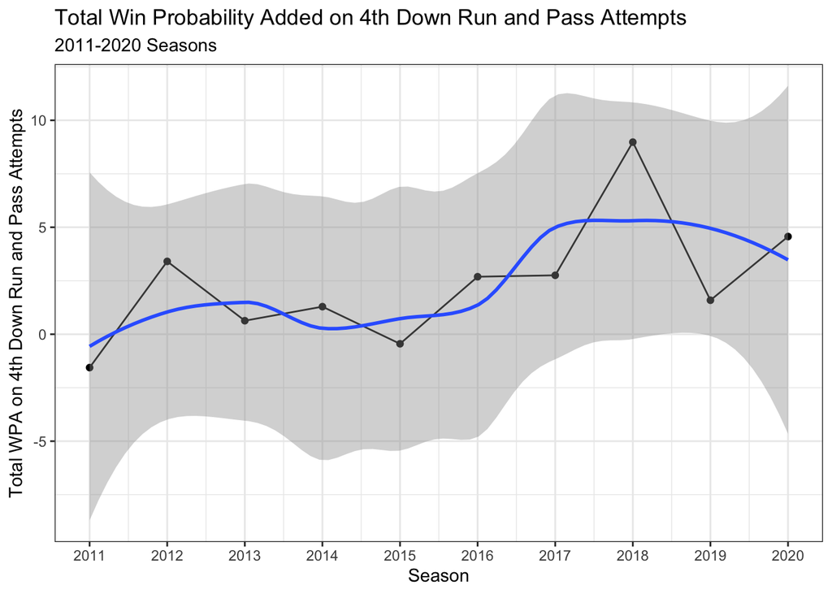

During the most recent 5 years, the WPA on fourth downs has been positive. While the graph does not follow the same drastic pattern as the number of attempts, it still provides evidence that WPA is greater during the seasons were more attempts were made. While there are some outliers, the Loess Smoother line shows a general upward trend in WPA over the 10 years supporting the idea that going for it more often improves win probability. It is important to acknowledge that aggression on 4th down does not always end in success. The decisions to go for it are supported statistically and will lead to positive results more often than not. The introduction of analytics into the NFL has uncovered an area where the numbers support going for it, so coaches utilizing these metrics when making a decision on 4th down will lead to more attempts being made.

#### Code utilized can be shown using button on the right

```r
# libraries
library(nflfastR)
library(dplyr)
library(ggplot2)

# nflfastR data being used from 2011-2020 seasons
pbp_10yr <- read.csv("pbp2011_2021.csv")

# 4th Down Trend Visualization
fourth_down <- pbp_10yr %>%
  filter(down == 4 & (play_type == "run" | play_type == "pass") & season != 2021) %>%
  group_by(season) %>%
  summarize(total = n())
fourth_down$season <- as.factor(fourth_down$season)

plot1 <- ggplot(data = fourth_down, aes(x = season, y = total)) +
  geom_point() +
  geom_line(aes(group = 1)) +
  labs(x = "Season", y = "Total 4th Down Run and Pass Attempts") +
  ggtitle("Total 4th Down Run and Pass Attempts From 2011-2020 Seasons") +
  theme_bw()

# WPA visualization
wpa_vis <- pbp_10yr %>%
  filter(down == 4 & (play_type == "pass" | play_type == "run") & season != 2021) %>%
  group_by(season) %>%
  summarise(total_wpa = sum(wpa))

plot2 <- ggplot(data = wpa_vis, aes(x = season, y = total_wpa)) +
  geom_point() +
  geom_line(aes(group = 1)) +
  geom_smooth(method = 'loess') +
  labs(x = "Season", y = "Total WPA on 4th Down Run and Pass Attempts") +
  ggtitle("Total Win Probability Added on 4th Down Run and Pass Attempts",
    subtitle = "2011-2020 Seasons") +
  theme_bw() +
  scale_x_continuous(breaks = pretty_breaks())
```